```python
import numpy as np
import pandas as pd
import seaborn as sns
import scipy.stats as stats
import matplotlib.pyplot as plt
```

```python
data = pd.read_csv("Bank_Personal_Loan_Modelling.csv")
```

# Analysing Data Distribution

```python
data.head(3)
```

|  | ID | Age | Experience | Income | ZIP Code | Family | CCAvg | Education | Mortgage | Personal Loan | Securities Account | CD Account | Online | CreditCard |
| --- | --- | --- | --- | --- | --- | --- | --- | --- | --- | --- | --- | --- | --- | --- |
| 0 | 1 | 25 | 1 | 49 | 91107 | 4 | 1.6 | 1 | 0 | 0 | 1 | 0 | 0 | 0 |
| 1 | 2 | 45 | 19 | 34 | 90089 | 3 | 1.5 | 1 | 0 | 0 | 1 | 0 | 0 | 0 |
| 2 | 3 | 39 | 15 | 11 | 94720 | 1 | 1.0 | 1 | 0 | 0 | 0 | 0 | 0 | 0 |

```python
data.info()
```

```
<class 'pandas.core.frame.DataFrame'>
RangeIndex: 5000 entries, 0 to 4999
Data columns (total 14 columns):
ID                    5000 non-null int64
Age                   5000 non-null int64
Experience            5000 non-null int64
Income                5000 non-null int64
ZIP Code              5000 non-null int64
Family                5000 non-null int64
CCAvg                 5000 non-null float64
Education             5000 non-null int64
Mortgage              5000 non-null int64
Personal Loan         5000 non-null int64
Securities Account    5000 non-null int64
CD Account            5000 non-null int64
Online                5000 non-null int64
CreditCard            5000 non-null int64
dtypes: float64(1), int64(13)
memory usage: 547.0 KB
```

```python
data.isnull().sum()
```

```
ID                    0
Age                   0
Experience            0
Income                0
ZIP Code              0
Family                0
CCAvg                 0
Education             0
Mortgage              0
Personal Loan         0
Securities Account    0
CD Account            0
Online                0
CreditCard            0
dtype: int64
```

```python
data.describe()
```

|  | ID | Age | Experience | Income | ZIP Code | Family | CCAvg | Education | Mortgage | Personal Loan | Securities Account | CD Account | Online | CreditCard |
| --- | --- | --- | --- | --- | --- | --- | --- | --- | --- | --- | --- | --- | --- | --- |
| count | 5000.000000 | 5000.000000 | 5000.000000 | 5000.000000 | 5000.000000 | 5000.000000 | 5000.000000 | 5000.000000 | 5000.000000 | 5000.000000 | 5000.000000 | 5000.00000 | 5000.000000 | 5000.000000 |
| mean | 2500.500000 | 45.338400 | 20.104600 | 73.774200 | 93152.503000 | 2.396400 | 1.937938 | 1.881000 | 56.498800 | 0.096000 | 0.104400 | 0.06040 | 0.596800 | 0.294000 |
| std | 1443.520003 | 11.463166 | 11.467954 | 46.033729 | 2121.852197 | 1.147663 | 1.747659 | 0.839869 | 101.713802 | 0.294621 | 0.305809 | 0.23825 | 0.490589 | 0.455637 |
| min | 1.000000 | 23.000000 | -3.000000 | 8.000000 | 9307.000000 | 1.000000 | 0.000000 | 1.000000 | 0.000000 | 0.000000 | 0.000000 | 0.00000 | 0.000000 | 0.000000 |
| 25% | 1250.750000 | 35.000000 | 10.000000 | 39.000000 | 91911.000000 | 1.000000 | 0.700000 | 1.000000 | 0.000000 | 0.000000 | 0.000000 | 0.00000 | 0.000000 | 0.000000 |
| 50% | 2500.500000 | 45.000000 | 20.000000 | 64.000000 | 93437.000000 | 2.000000 | 1.500000 | 2.000000 | 0.000000 | 0.000000 | 0.000000 | 0.00000 | 1.000000 | 0.000000 |
| 75% | 3750.250000 | 55.000000 | 30.000000 | 98.000000 | 94608.000000 | 3.000000 | 2.500000 | 3.000000 | 101.000000 | 0.000000 | 0.000000 | 0.00000 | 1.000000 | 1.000000 |
| max | 5000.000000 | 67.000000 | 43.000000 | 224.000000 | 96651.000000 | 4.000000 | 10.000000 | 3.000000 | 635.000000 | 1.000000 | 1.000000 | 1.00000 | 1.000000 | 1.000000 |

```
array([[<matplotlib.axes._subplots.AxesSubplot object at 0x0000014D9338F388>,
      dtype=object)
```

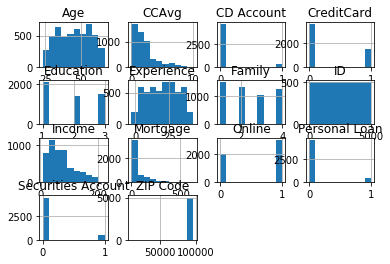

```python
data.hist()
```

```python
stats.skew(data["Age"])
```

```
-0.029331878574766698
```

```python
stats.skew(data["Experience"])
```

```
-0.026316790337654442
```

```python
stats.skew(data["Income"])
```

```
0.8410861846424931
```

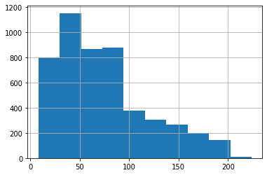

```python
data['Income'].hist()
```

Considering these parameters age and experience do not have significant skewness Income of the people included in our data is moderately skewed towards lower side

```python
Age = data["Age"]
Experience = data["Experience"]
Income = data["Income"]
from pylab import *
from matplotlib.patches import Polygon
import matplotlib.pyplot as plt
import matplotlib.transforms as mtransforms
```

```
{'whiskers': [<matplotlib.lines.Line2D at 0x16ffb049d48>,
 'caps': [<matplotlib.lines.Line2D at 0x16ffb049ec8>,
 'boxes': [<matplotlib.lines.Line2D at 0x16ffb0494c8>,
 'medians': [<matplotlib.lines.Line2D at 0x16ffb055b88>,
 'fliers': [<matplotlib.lines.Line2D at 0x16ffb05cc48>,
 'means': []}
```

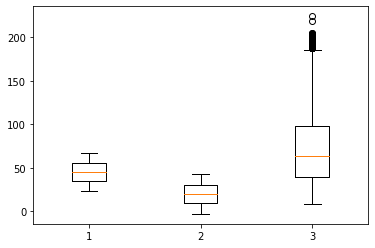

```python
plt.boxplot(x=[Age,Experience,Income])
```

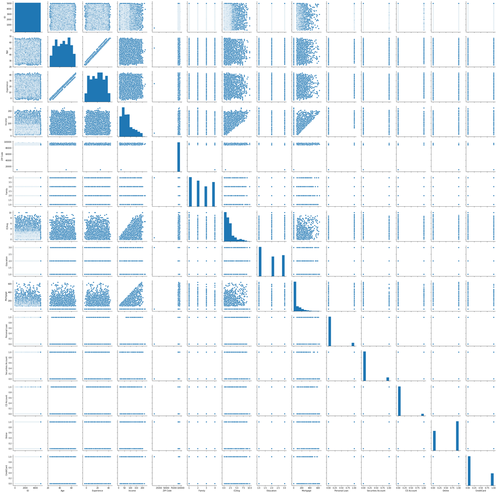

```python
sns.pairplot(data)
```

```python
Age and experience do not have significant skewness
there is moderate skewness in income
age and experience are seen to be linearly related with each other
```

# Target Coulmn Distribution

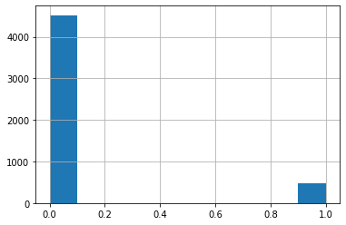

```python
data['Personal Loan'].hist()
```

```python
yesloan = data[data['Personal Loan'] ==1]
```

```python
yesloan.head()
```

|  | ID | Age | Experience | Income | ZIP Code | Family | CCAvg | Education | Mortgage | Personal Loan | Securities Account | CD Account | Online | CreditCard |
| --- | --- | --- | --- | --- | --- | --- | --- | --- | --- | --- | --- | --- | --- | --- |
| 9 | 10 | 34 | 9 | 180 | 93023 | 1 | 8.9 | 3 | 0 | 1 | 0 | 0 | 0 | 0 |
| 16 | 17 | 38 | 14 | 130 | 95010 | 4 | 4.7 | 3 | 134 | 1 | 0 | 0 | 0 | 0 |
| 18 | 19 | 46 | 21 | 193 | 91604 | 2 | 8.1 | 3 | 0 | 1 | 0 | 0 | 0 | 0 |
| 29 | 30 | 38 | 13 | 119 | 94104 | 1 | 3.3 | 2 | 0 | 1 | 0 | 1 | 1 | 1 |
| 38 | 39 | 42 | 18 | 141 | 94114 | 3 | 5.0 | 3 | 0 | 1 | 1 | 1 | 1 | 0 |

```python
noloan=data[data['Personal Loan'] ==0]
```

```python
noloan.head()
```

|  | ID | Age | Experience | Income | ZIP Code | Family | CCAvg | Education | Mortgage | Personal Loan | Securities Account | CD Account | Online | CreditCard |
| --- | --- | --- | --- | --- | --- | --- | --- | --- | --- | --- | --- | --- | --- | --- |
| 0 | 1 | 25 | 1 | 49 | 91107 | 4 | 1.6 | 1 | 0 | 0 | 1 | 0 | 0 | 0 |
| 1 | 2 | 45 | 19 | 34 | 90089 | 3 | 1.5 | 1 | 0 | 0 | 1 | 0 | 0 | 0 |
| 2 | 3 | 39 | 15 | 11 | 94720 | 1 | 1.0 | 1 | 0 | 0 | 0 | 0 | 0 | 0 |
| 3 | 4 | 35 | 9 | 100 | 94112 | 1 | 2.7 | 2 | 0 | 0 | 0 | 0 | 0 | 0 |
| 4 | 5 | 35 | 8 | 45 | 91330 | 4 | 1.0 | 2 | 0 | 0 | 0 | 0 | 0 | 1 |

```python
yesloan.describe()
```

|  | ID | Age | Experience | Income | ZIP Code | Family | CCAvg | Education | Mortgage | Personal Loan | Securities Account | CD Account | Online | CreditCard |
| --- | --- | --- | --- | --- | --- | --- | --- | --- | --- | --- | --- | --- | --- | --- |
| count | 480.000000 | 480.000000 | 480.000000 | 480.000000 | 480.000000 | 480.000000 | 480.000000 | 480.000000 | 480.000000 | 480.0 | 480.000000 | 480.000000 | 480.00000 | 480.000000 |
| mean | 2390.650000 | 45.066667 | 19.843750 | 144.745833 | 93153.202083 | 2.612500 | 3.905354 | 2.233333 | 100.845833 | 1.0 | 0.125000 | 0.291667 | 0.60625 | 0.297917 |
| std | 1394.393674 | 11.590964 | 11.582443 | 31.584429 | 1759.223753 | 1.115393 | 2.097681 | 0.753373 | 160.847862 | 0.0 | 0.331064 | 0.455004 | 0.48909 | 0.457820 |
| min | 10.000000 | 26.000000 | 0.000000 | 60.000000 | 90016.000000 | 1.000000 | 0.000000 | 1.000000 | 0.000000 | 1.0 | 0.000000 | 0.000000 | 0.00000 | 0.000000 |
| 25% | 1166.500000 | 35.000000 | 9.000000 | 122.000000 | 91908.750000 | 2.000000 | 2.600000 | 2.000000 | 0.000000 | 1.0 | 0.000000 | 0.000000 | 0.00000 | 0.000000 |
| 50% | 2342.000000 | 45.000000 | 20.000000 | 142.500000 | 93407.000000 | 3.000000 | 3.800000 | 2.000000 | 0.000000 | 1.0 | 0.000000 | 0.000000 | 1.00000 | 0.000000 |
| 75% | 3566.000000 | 55.000000 | 30.000000 | 172.000000 | 94705.500000 | 4.000000 | 5.347500 | 3.000000 | 192.500000 | 1.0 | 0.000000 | 1.000000 | 1.00000 | 1.000000 |
| max | 4981.000000 | 65.000000 | 41.000000 | 203.000000 | 96008.000000 | 4.000000 | 10.000000 | 3.000000 | 617.000000 | 1.0 | 1.000000 | 1.000000 | 1.00000 | 1.000000 |

```python
noloan.describe()
```

|  | ID | Age | Experience | Income | ZIP Code | Family | CCAvg | Education | Mortgage | Personal Loan | Securities Account | CD Account | Online | CreditCard |
| --- | --- | --- | --- | --- | --- | --- | --- | --- | --- | --- | --- | --- | --- | --- |
| count | 4520.000000 | 4520.000000 | 4520.000000 | 4520.000000 | 4520.000000 | 4520.000000 | 4520.000000 | 4520.000000 | 4520.000000 | 4520.0 | 4520.000000 | 4520.000000 | 4520.000000 | 4520.000000 |
| mean | 2512.165487 | 45.367257 | 20.132301 | 66.237389 | 93152.428761 | 2.373451 | 1.729009 | 1.843584 | 51.789381 | 0.0 | 0.102212 | 0.035841 | 0.595796 | 0.293584 |
| std | 1448.299331 | 11.450427 | 11.456672 | 40.578534 | 2156.949654 | 1.148771 | 1.567647 | 0.839975 | 92.038931 | 0.0 | 0.302961 | 0.185913 | 0.490792 | 0.455454 |
| min | 1.000000 | 23.000000 | -3.000000 | 8.000000 | 9307.000000 | 1.000000 | 0.000000 | 1.000000 | 0.000000 | 0.0 | 0.000000 | 0.000000 | 0.000000 | 0.000000 |
| 25% | 1259.750000 | 35.000000 | 10.000000 | 35.000000 | 91911.000000 | 1.000000 | 0.600000 | 1.000000 | 0.000000 | 0.0 | 0.000000 | 0.000000 | 0.000000 | 0.000000 |
| 50% | 2518.500000 | 45.000000 | 20.000000 | 59.000000 | 93437.000000 | 2.000000 | 1.400000 | 2.000000 | 0.000000 | 0.0 | 0.000000 | 0.000000 | 1.000000 | 0.000000 |
| 75% | 3768.250000 | 55.000000 | 30.000000 | 84.000000 | 94608.000000 | 3.000000 | 2.300000 | 3.000000 | 98.000000 | 0.0 | 0.000000 | 0.000000 | 1.000000 | 1.000000 |
| max | 5000.000000 | 67.000000 | 43.000000 | 224.000000 | 96651.000000 | 4.000000 | 8.800000 | 3.000000 | 635.000000 | 0.0 | 1.000000 | 1.000000 | 1.000000 | 1.000000 |

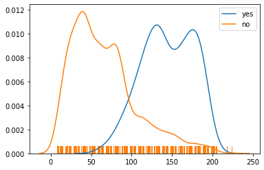

```python
sns.distplot(yesloan[['Income']], hist= False, rug=True, label=("yes"))
sns.distplot(noloan[['Income']], hist= False, rug=True, label=("no"))
```

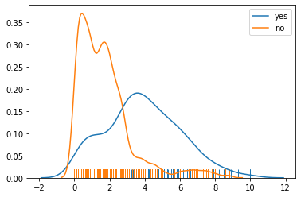

```python
sns.distplot(yesloan[['CCAvg']], hist= False, rug=True, label=("yes"))
sns.distplot(noloan[['CCAvg']], hist= False, rug=True, label=("no"))
```

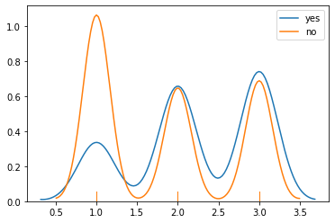

```python
sns.distplot(yesloan[['Education']], hist= False, rug=True, label=("yes"))
sns.distplot(noloan[['Education']], hist= False, rug=True, label=("no"))
```

# Comments

Target Column : Personal Loan Desired output : 1, i.e., loan was accepted by the customer. 480 people out of 5000 accepted the loan.

out of the independent variables - ID and ZIP code have no significant effect on our target column Comparing the group of people who accepted loan and who didn't, there is some mean difference as evident from the plots in Income, CCAvg, Education and Mortgage

most of the people with low income and low CCAvg tend to be in the group who didn't accept loan So these factors could be useful predictors. Whereas other factors though not obvious might play an indirect role which would be studied in our models.

# Splitting Data

```python
import matplotlib as mpl
import matplotlib.pyplot as plt
from sklearn.model_selection import train_test_split
from sklearn import linear_model
import statsmodels.api as sm
from sklearn import metrics
from sklearn import datasets
import seaborn as sn
%matplotlib inline
```

```python
# before splitting, lets drop ID which have no influence
data = data.drop('ID', axis=1)
```

```python
#lets replace categorical variable with original
data['Education']= data['Education'].replace({1:'undergrad', 2:'graduate',3:'advanced'})
```

```python
data = pd.get_dummies(data, columns=['Education'])
data.head()
```

|  | Age | Experience | Income | ZIP Code | Family | CCAvg | Mortgage | Personal Loan | Securities Account | CD Account | Online | CreditCard | Education_advanced | Education_graduate | Education_undergrad |
| --- | --- | --- | --- | --- | --- | --- | --- | --- | --- | --- | --- | --- | --- | --- | --- |
| 0 | 25 | 1 | 49 | 91107 | 4 | 1.6 | 0 | 0 | 1 | 0 | 0 | 0 | 0 | 0 | 1 |
| 1 | 45 | 19 | 34 | 90089 | 3 | 1.5 | 0 | 0 | 1 | 0 | 0 | 0 | 0 | 0 | 1 |
| 2 | 39 | 15 | 11 | 94720 | 1 | 1.0 | 0 | 0 | 0 | 0 | 0 | 0 | 0 | 0 | 1 |
| 3 | 35 | 9 | 100 | 94112 | 1 | 2.7 | 0 | 0 | 0 | 0 | 0 | 0 | 0 | 1 | 0 |
| 4 | 35 | 8 | 45 | 91330 | 4 | 1.0 | 0 | 0 | 0 | 0 | 0 | 1 | 0 | 1 | 0 |

```python
x = data.drop(['Personal Loan','Education_advanced'], axis=1)
# the dependent variable
y = data[['Personal Loan']]
```

```python
x_train, x_test, y_train, y_test = train_test_split(x, y, test_size=0.30, random_state=1)
```

```python
y_train.describe()
```

|  | Personal Loan |
| --- | --- |
| count | 3500.000000 |
| mean | 0.094571 |
| std | 0.292664 |
| min | 0.000000 |
| 25% | 0.000000 |
| 50% | 0.000000 |
| 75% | 0.000000 |
| max | 1.000000 |

```python
y_test.describe()
```

|  | Personal Loan |
| --- | --- |
| count | 1500.000000 |
| mean | 0.099333 |
| std | 0.299209 |
| min | 0.000000 |
| 25% | 0.000000 |
| 50% | 0.000000 |
| 75% | 0.000000 |
| max | 1.000000 |

# Logistic regression,KNN and Naive Bayes models

# a) Logistic regression

```python
from sklearn import metrics

from sklearn.linear_model import LogisticRegression

# Fit the model on train
model = LogisticRegression(solver="liblinear")
model.fit(x_train, y_train.values.ravel())
#predict on test
y_pred1 = model.predict(x_test)

coef_df = pd.DataFrame(model.coef_)
coef_df['intercept'] = model.intercept_
print(coef_df)
```

```
          0         1         2         3         4        5         6  \
0 -0.000031 -0.312341  0.312816  0.052774  0.541161  0.18912  0.000898

          7         8         9        10        11        12  intercept
0 -0.249728  2.409409 -0.501307 -0.584072 -0.205845 -3.691121  -0.355587
```

```python
model_score = model.score(x_test, y_test)
print(model_score)
```

```
0.9553333333333334
```

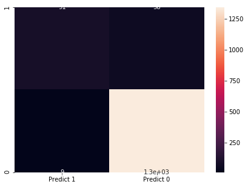

```python
cm=metrics.confusion_matrix(y_test, y_pred1, labels=[1, 0])

df_cm = pd.DataFrame(cm, index = [i for i in ["1","0"]],
                  columns = [i for i in ["Predict 1","Predict 0"]])
plt.figure(figsize = (7,5))
sns.heatmap(df_cm, annot=True)
```

```python
cm = confusion_matrix (y_test, y_pred1)

print (cm)
```

```
[[1342    9]
 [  58   91]]
```

```python
pred_proba_df = pd.DataFrame(model.predict_proba(x_test))
threshold_list = [0.05,0.1,0.15,0.2,0.25,0.3,0.35,0.4,0.45,0.5,0.55,0.6,0.65,.7,.75,.8,.85,.9,.95,.99]
for i in threshold_list:
    print ('\n******** For i = {} ******'.format(i))
    y_pred1 = pred_proba_df.applymap(lambda x: 1 if x>i else 0)
    test_accuracy = metrics.accuracy_score(y_test.as_matrix().reshape(y_test.as_matrix().size,1),
                                           y_pred1.iloc[:,1].as_matrix().reshape(y_pred1.iloc[:,1].as_matrix().size,1))
    print('Our testing accuracy is {}'.format(test_accuracy))
    print(confusion_matrix(y_test.as_matrix().reshape(y_test.as_matrix().size,1),
                           y_pred1.iloc[:,1].as_matrix().reshape(y_pred1.iloc[:,1].as_matrix().size,1)))
```

```
******** For i = 0.05 ******
Our testing accuracy is 0.8413333333333334
[[1123  228]
 [  10  139]]

******** For i = 0.1 ******
Our testing accuracy is 0.898
[[1215  136]
 [  17  132]]

******** For i = 0.15 ******
Our testing accuracy is 0.926
[[1261   90]
 [  21  128]]

******** For i = 0.2 ******
Our testing accuracy is 0.94
[[1291   60]
 [  30  119]]

******** For i = 0.25 ******
Our testing accuracy is 0.9466666666666667
[[1308   43]
 [  37  112]]

******** For i = 0.3 ******
Our testing accuracy is 0.952
[[1320   31]
 [  41  108]]

******** For i = 0.35 ******
Our testing accuracy is 0.954
[[1327   24]
 [  45  104]]

******** For i = 0.4 ******
Our testing accuracy is 0.956
[[1334   17]
 [  49  100]]

```

[output cut: 44 more lines]

```

******** For i = 0.9 ******
Our testing accuracy is 0.9313333333333333
[[1351    0]
 [ 103   46]]

******** For i = 0.95 ******
Our testing accuracy is 0.9226666666666666
[[1351    0]
 [ 116   33]]

******** For i = 0.99 ******
Our testing accuracy is 0.904
[[1351    0]
 [ 144    5]]
```

```python
#sensitivity
from sklearn.metrics import recall_score
print(metrics.recall_score(y_test, y_pred1))
```

```
0.610738255033557
```

```python
from sklearn.metrics import f1_score
from sklearn.metrics import average_precision_score
f1 = f1_score(y_test, y_pred1)
ap = average_precision_score(y_test, y_pred1)
f1, ap
```

```
(0.7309236947791165, 0.5944384787472036)
```

# recall = 0.61 average precision= 0.59 f1 score = 0.73

```python
from sklearn.metrics import roc_curve
from sklearn.metrics import roc_auc_score
fpr1, tpr1, thresholds = roc_curve(y_test, y_pred1)
auc = roc_auc_score(y_test, test_predict)
print('AUC: %.3f' % auc)
```

[output not shown]

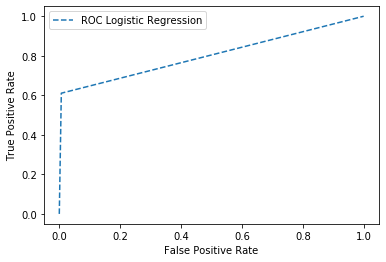

```python
from matplotlib import pyplot
pyplot.plot(fpr1,tpr1, linestyle='--', label='ROC Logistic Regression')
pyplot.xlabel('False Positive Rate')
pyplot.ylabel('True Positive Rate')
pyplot.legend()
pyplot.show()
```